# StarTrek-Bechdel

Zane Dax

09/08/2021

# Bechdel-Wallace Test of Star Trek DS9

This data is testing if the episodes per season of the TV show Star Trek DS9 pass or fail the **Bechdel-Wallace** test. For more information check the *Bechdel-test.md* file. Simple criteria for the test to end in a pass is the following:

## Criteria :

1. must have 2+ named women
2. named women talk to each other
3. topic of discussion is not a man/ men including regarding relationship(s)

## Read in the dataset

> ds9 = read.csv(‘StarTrek-DS9.csv’)

## Episodes per season

> ds9 %>% count(Season)

```
  Season     n
   <dbl> <int>
1      1    19
2      2    26
3      3    26
4      4    25
5      5    26
6      6    26
7      7    25
```

## Bechdel-Wallace initial pass/fail

> ds9 %>% count(`Bechdel-Wallace`) %>%  
> ggplot( aes(x= `Bechdel-Wallace`, y= n ) ) +  
> geom_col( fill= c(“#cc0000”,‘#00cc00’)) +  
> labs(title = “Star Trek DS9 Bechdel-Wallace Test”,  
> subtitle = “Total number of pass and fails per episode”)

The number of fails of the Bechdel-Wallace test are 152 and the number of passes is 21.

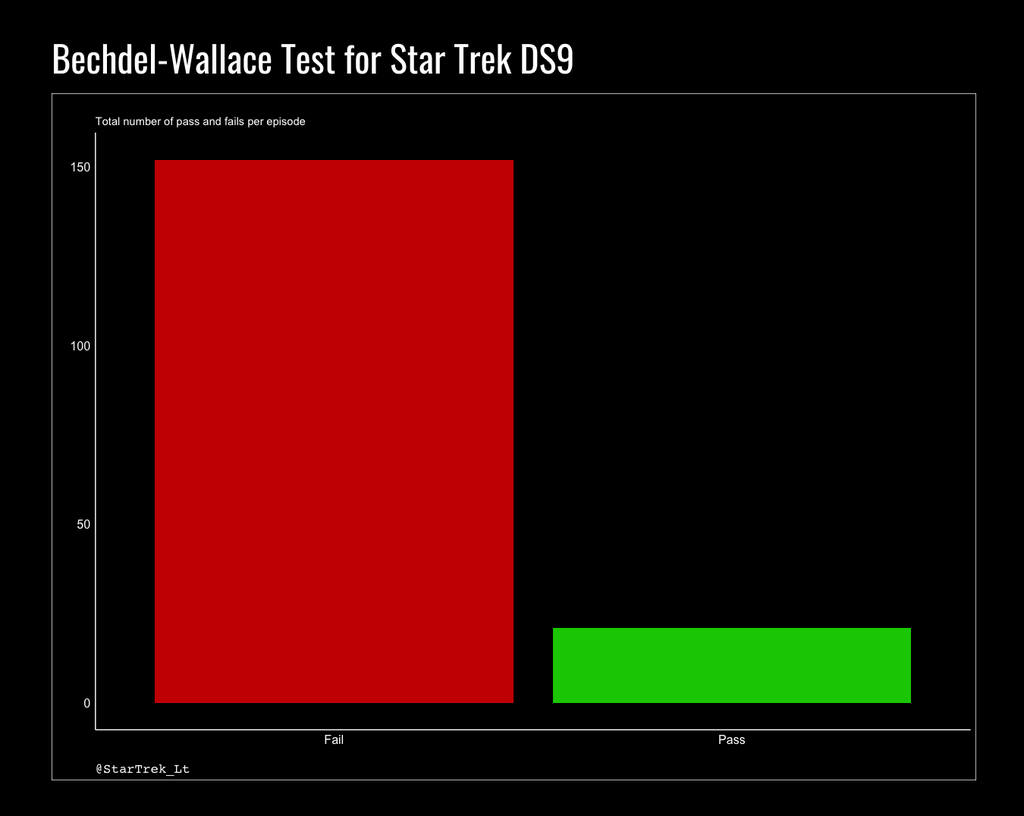

## DS9 Directors by Gender

> ds9 %>%  
> select(Director_Gender,  
> Writer_Gender, Episode, `Bechdel-Wallace`) %>%  
> group_by(Director_Gender) %>%  
> count()

Female directors count is 7 while the Male directors is 166.

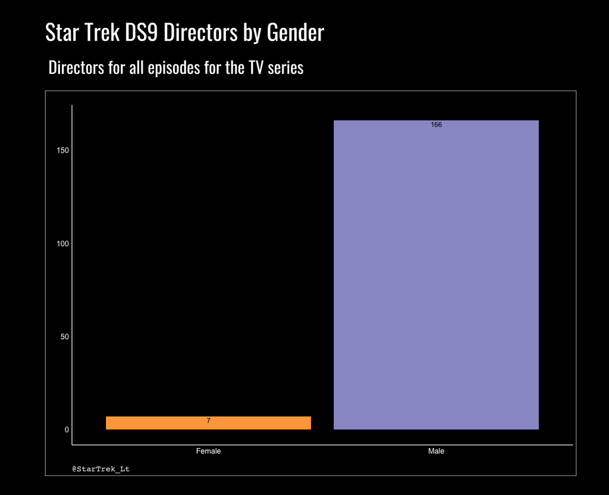

## DS9 Director’s Gender & Bechdel Test

> ds9 %>%  
> select(`Bechdel-Wallace`, Director_Gender, Episode, Season) %>%  
> # filter(`Bechdel-Wallace` ==“Pass”) %>%  
> group_by(Episode,`Bechdel-Wallace`)

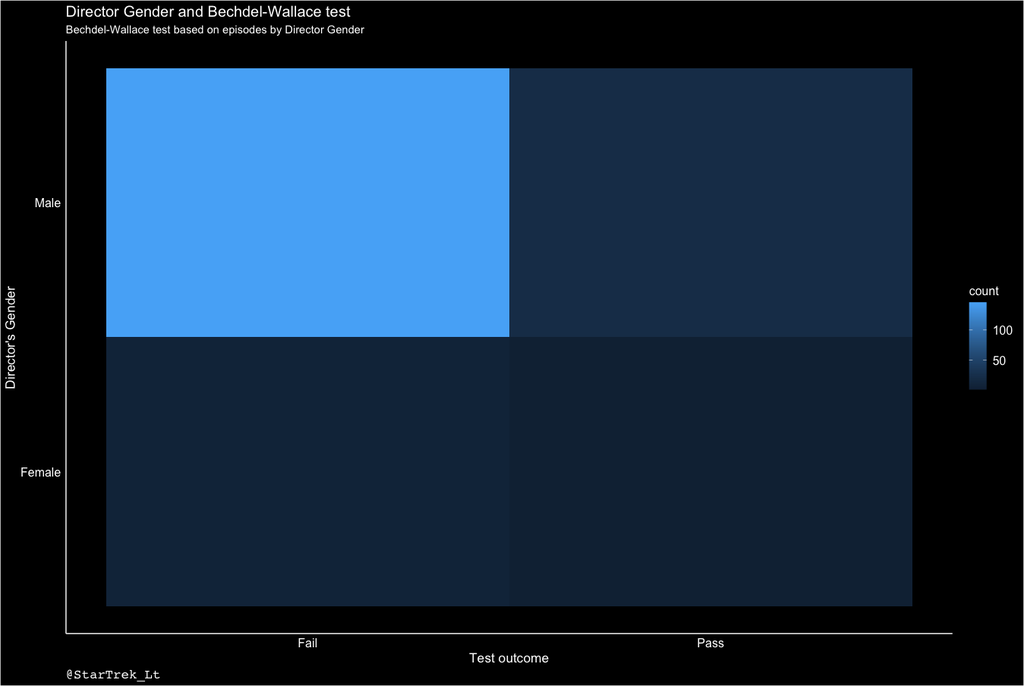

## DS9 Female Directors Episodes

> ds9 %>%  
> filter(Director_Gender == “Female”) %>%  
> select(Title, Director, Season)

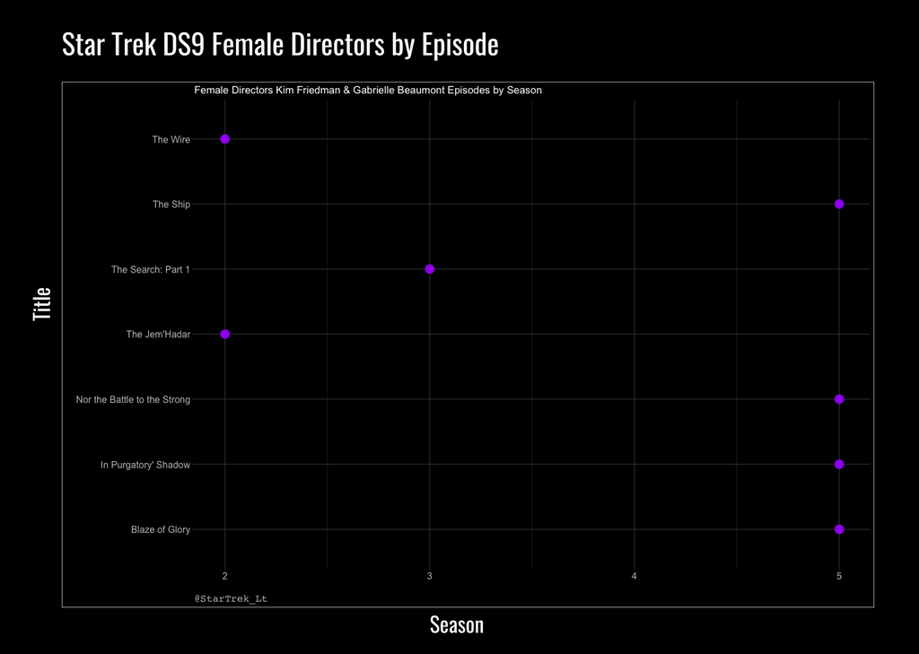

## DS9 Writers with 1 or more Female by Season

> ds9 %>%  
> filter(Writer_Gender ==“Female”) %>%  
> select(Title, Writer_Gender, Season, Episode, Written_By)

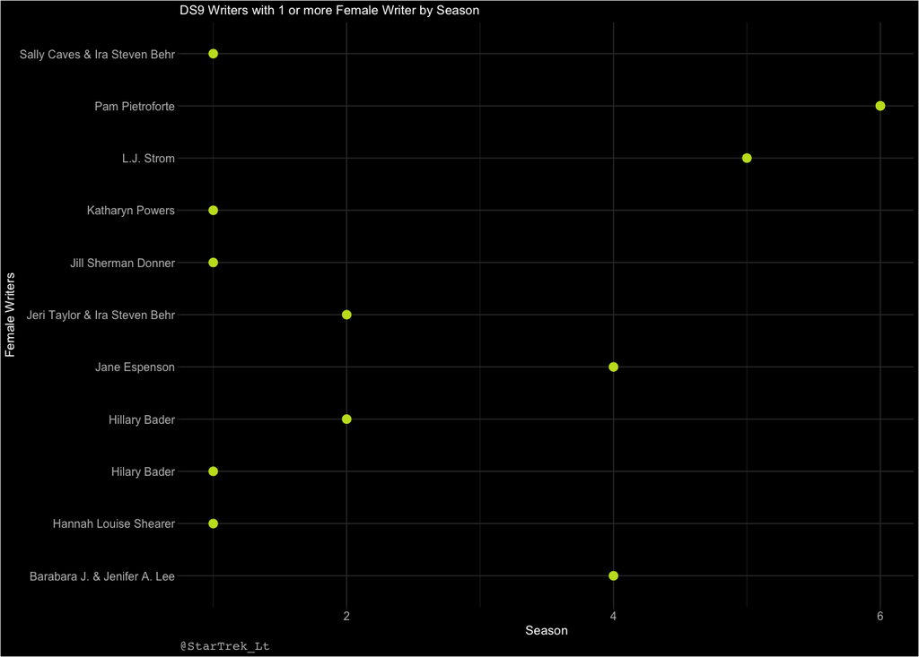

## DS9 Female (only) Writers by Season

> ds9 %>%  
> select(Season, Director_Gender, Writer_Gender) %>%  
> group_by(Season,Writer_Gender) %>%  
> filter(Writer_Gender ==“Female”) %>%  
> count()

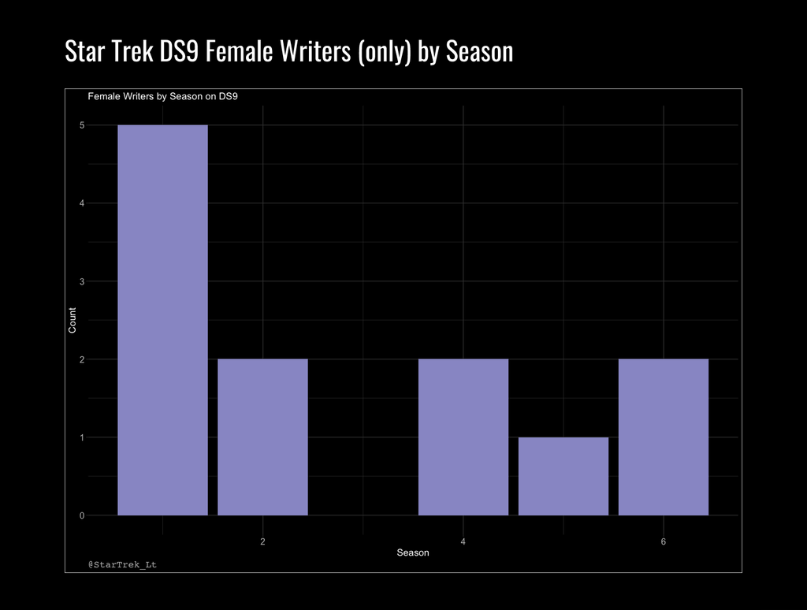

## DS9 Bechdel-Wallace Passes by Season

The data for the barchart is selected on pass variable and there is only 1 female Director (Season 2), a total of 2 female writers (1 female in Season 1, and in Season 2: 1 female + male)

> ds9 %>%  
> filter(`Bechdel-Wallace` ==“Pass”) %>%  
> select(Season,Episode,Writer_Gender,Director_Gender)

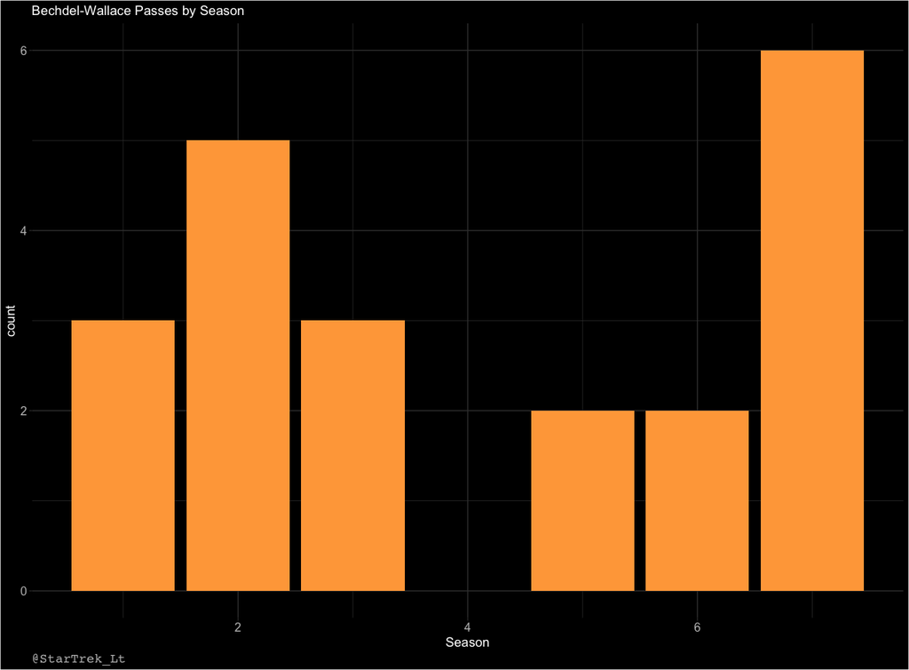

## DS9 Writers by Gender grouping

> ds9 %>%  
> group_by(Writer_Gender) %>%  
> count()

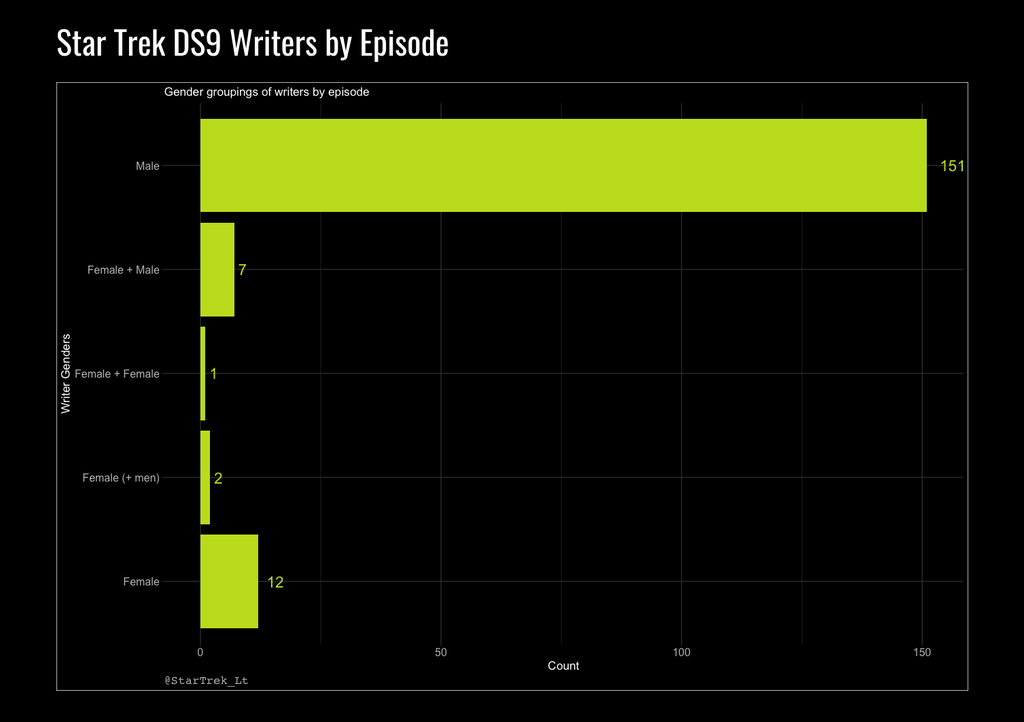

## Linear Regression

A linear regression model was conducted to see if there was any affect a Director or Writer’s gender had on if it passed or failed the Bechdel-Wallace test.

```
  Call:
  lm(formula = Bechdel ~ Director_Gender + Writer_Gender + Season,
      data = ds9)

  Residuals:
      Min      1Q  Median      3Q     Max
  -0.1514 -0.1287 -0.1233 -0.1178  0.9117

  Coefficients:
                                Estimate Std. Error t value Pr(>|t|)
  (Intercept)                   1.105551   0.164569   6.718 2.81e-10 ***
  Director_GenderMale          -0.014517   0.129410  -0.112    0.911
  Writer_GenderFemale (+ men)  -0.085598   0.254370  -0.337    0.737
  Writer_GenderFemale + Female -0.088316   0.347191  -0.254    0.800
  Writer_GenderFemale + Male    0.059456   0.159669   0.372    0.710
  Writer_GenderMale             0.045844   0.101841   0.450    0.653
  Season                       -0.002718   0.013483  -0.202    0.841
  ---
  Signif. codes:  0 ‘***’ 0.001 ‘**’ 0.01 ‘*’ 0.05 ‘.’ 0.1 ‘ ’ 1

  Residual standard error: 0.3327 on 166 degrees of freedom
  Multiple R-squared:  0.004003,    Adjusted R-squared:  -0.032
  F-statistic: 0.1112 on 6 and 166 DF,  p-value: 0.995
```

As you can see that there is no statistically signifant affect of either writer or director’s gender has on if an episode passes the Bechdel-Wallace test.